# Finding Fish in the Sound of the Sea

How Marine Acoustic Monitoring Revealed Hidden Patterns in Ocean Life

Author

Marine Biodiversity Observation Network (MBON)

Published

September 23, 2025

## The Challenge: Listening for Life in a Noisy Ocean

Imagine trying to identify individual bird songs in a bustling city park, except the “park” is the entire ocean, the recording never stops, and you need to catalog not just one type of bird, but dozens of fish species, each with their own unique vocal patterns. This is the challenge facing marine biologists who study ocean ecosystems using underwater microphones, called hydrophones.

Every day, these sophisticated listening devices capture thousands of hours of ocean sounds - from the grunts and calls of fish during spawning season to the whistles of dolphins and the rumble of passing ships. Hidden within this acoustic tapestry are clues about marine life abundance, behavior, and ecosystem health. But finding these biological signals in vast datasets has traditionally required experts to manually listen through recordings, a process so time-intensive that it creates a bottleneck limiting our understanding of ocean ecosystems.

## Building on Previous Research

This work builds on important foundational studies, particularly research by Transue et al. (2023) who demonstrated that environmental factors like water temperature are strong predictors of fish vocal activity in Charleston Harbor. Their work showed that traditional machine learning approaches could identify some patterns in when and where fish are most likely to be acoustically active.

**What we’re adding**: While previous studies focused on environmental predictors alone, we asked a different question: *Can the acoustic characteristics of the ocean itself - the “soundscape” - tell us something about biological activity that environmental data alone cannot?*

Our approach combines environmental monitoring (temperature, depth, currents) with acoustic indices - mathematical measures that capture different aspects of underwater sound complexity, from background noise levels to the diversity of simultaneous sounds.

## The Data Pipeline: From Ocean Sounds to Scientific Insights

Our study used acoustic monitoring data from three underwater listening stations in coastal waters, collecting:

- **13,100 individual time periods** (2-hour chunks) during 2021
- **10 different acoustic indices** measuring sound complexity, diversity, and intensity
- **Environmental measurements** including temperature, depth, and ambient sound levels
- **Expert-verified detections** of six marine species:
  - Silver perch (grunts and calls)
  - Oyster toadfish (distinctive “boat whistle” sound)
  - Spotted seatrout (drumming sounds)
  - Atlantic croaker (croaking calls)
  - Red drum (drumming sounds)
  - Vessel noise (as a comparison)

### Data Alignment: Syncing the Ocean’s Clock

One of the biggest technical challenges was aligning different data streams that operated on different schedules:

- **Acoustic recordings**: Continuous, analyzed in 2-hour blocks
- **Fish detections**: Irregular timing based on biological activity
- **Environmental sensors**: Various sampling intervals (15 minutes to 1 hour)

We developed a sophisticated temporal alignment system that matched all data sources to consistent 2-hour time windows, ensuring that when we say “temperature was 18°C when silver perch were calling,” we’re comparing measurements from the same time and place.

### Feature Engineering: Teaching Computers to “Hear” Like Marine Biologists

Marine biologists don’t just listen for individual fish calls - they listen for patterns: “The dawn chorus is starting,” or “This sounds like spawning season.” We translated this expert knowledge into mathematical features:

**Acoustic Indices** (What the soundscape tells us): - **Background noise levels**: How quiet or noisy is the ocean? - **Sound diversity**: How many different sound sources are present? - **Frequency patterns**: Are sounds concentrated in low frequencies (large fish) or high frequencies (small fish)? - **Acoustic complexity**: Simple steady sounds vs. complex changing patterns

**Environmental Context**: - **Water temperature** and its recent changes (fish are cold-blooded!) - **Seasonal timing**: Day of year and time of day - **Ambient sound levels**: Natural vs. human-caused noise

## The Traditional Approach: Machine Learning Meets Marine Biology

### First Attempts: Classic Prediction Models

Our initial approach followed standard machine learning practice: *Given current conditions, can we predict whether fish will be calling?* We tested three types of models:

- **Logistic Regression**: Linear relationships between features and fish activity
- **Random Forest**: Complex interactions between multiple environmental factors
- **Decision Trees**: Simple if-then rules (e.g., “If temperature > 20°C and month = June, then expect fish calls”)

### The Temperature Discovery

When we included temporal patterns - how conditions had been changing over recent hours and days - a clear winner emerged: **water temperature was by far the strongest predictor of fish vocal activity**.

This makes perfect biological sense. Fish are cold-blooded animals whose metabolism, behavior, and reproduction are directly tied to water temperature. Spawning seasons, daily activity patterns, and calling behavior all follow temperature cues that have been shaped by millions of years of evolution.

### The Seasonality Challenge

But here’s where traditional machine learning hit a wall. These models struggled with the fundamental challenge of seasonal data: **How do you predict summer fish activity using winter training data?**

Fish don’t call randomly throughout the year. They have distinct seasons - spawning periods, migration times, dormant phases. A model trained on summer data (lots of fish calls) would confidently predict activity in winter (complete silence), and vice versa. The models were fighting against biology instead of working with it.

## The Breakthrough: From Prediction to Guidance

### The Key Insight: Pattern Recognition over Time Prediction

Looking at our initial results, we had a realization: **What if we’re asking the wrong question?**

Instead of “Will fish be calling tomorrow?” (prediction), what if we asked “When should we focus our limited time listening for fish calls?” (guidance).

This shift led us to examine our data in a completely new way - as **2D probability surfaces** that map the likelihood of fish activity across two dimensions: - **Day of year** (seasonal patterns) - **Time of day** (daily rhythms)

### Visualizing the Hidden Patterns

These weren’t just statistical artifacts - they were visualizations of the biological rhythms that govern marine life.

## The Data Detective Work: Correlations and Feature Selection

### Finding the Signal in the Noise

This is like being a detective with dozens of potential clues - you need to figure out which ones are actually related to the mystery you’re trying to solve. We used a statistical technique called mutual information to measure how much each acoustic index “knows” about fish calling behavior.

[figure not shown]

*Figure 1: Heat map showing correlations between acoustic indices and fish detections. Warmer colors indicate stronger relationships between sound characteristics and biological activity.*

### The Feature Selection Discovery

Our correlation analysis revealed some fascinating insights:

**Top Predictive Acoustic Indices:** - **BGNf (Background Noise)**: Quieter periods often coincide with fish calls - **NDSI (Normalized Difference Soundscape Index)**: Measures balance between biological and human sounds - **H_pairedShannon (Shannon Diversity)**: More diverse soundscapes often contain fish calls - **LEQf (Sound Level)**: Specific sound intensity ranges associated with biological activity

[figure not shown]

*Figure 2: Comparison of feature importance between acoustic indices and environmental variables. Note how temperature dominates, but several acoustic indices provide complementary information.*

### Environmental vs. Acoustic: The Face-Off

When we compared the predictive power of environmental variables versus acoustic indices, the results were striking:

**Environmental Variables (Traditional Approach):** - Water temperature: Mutual information = 0.17 - Temperature changes over 2-6 hours: Strong secondary predictors - Seasonal timing: Important for long-term patterns

**Acoustic Indices (Our Innovation):** - Best acoustic indices: Mutual information = 0.09-0.12 - Multiple indices needed to match single temperature measurement - But they capture different information - **complementary, not redundant**

[figure not shown]

*Figure 3: Bar chart comparing the predictive power of different feature types. Environmental features (especially temperature) show higher individual scores, but acoustic features add unique information.*

## The Traditional Machine Learning Journey

### Three Models, One Clear Winner

We tested our features using three classic machine learning approaches:

**Logistic Regression**: The mathematician’s choice - Assumes linear relationships between features and outcomes - Easy to interpret: “Each 1°C temperature increase doubles the odds of fish calls” - Performance: Good baseline, but missed complex patterns

**Decision Trees**: The biologist’s favorite - Creates simple if-then rules: “If temperature > 22°C AND month = May, then expect oyster toadfish” - Easy to understand and explain to stakeholders - Performance: Moderate, prone to overfitting

**Random Forest**: The ensemble approach - Combines hundreds of decision trees for robust predictions - Handles complex interactions between multiple variables - Performance: **Best overall results**

[figure not shown]

*Figure 4: Performance comparison across different machine learning models. Random Forest consistently outperformed simpler approaches, especially when temporal features were included.*

### The Temperature Revelation

As we refined our models and added temporal features (how conditions had been changing over recent hours), one finding became unmistakable:

**Water temperature is the master controller of fish vocal activity.**

This wasn’t just statistically significant - it was biologically profound. Our models showed:

- **Temperature thresholds**: Each species has optimal calling temperatures
- **Temperature trends**: Fish respond to warming/cooling patterns, not just current temperature
- **Lag effects**: Temperature changes today influence calling behavior tomorrow

[figure not shown]

*Figure 5: Scatter plots showing the relationship between water temperature and fish calling activity for different species. Each species shows distinct temperature preferences and thresholds.*

### The Seasonality Brick Wall

But then we hit the fundamental problem that derails most marine acoustic monitoring projects: **seasonality**.

Our models were excellent at identifying patterns within a season, but they failed catastrophically when asked to generalize across seasons. A model trained on summer data (fish calling actively) would confidently predict high activity in winter (when fish are behaviorally dormant).

[figure not shown]

*Figure 6: Model predictions vs. actual observations across seasons, showing how traditional ML approaches fail to handle the fundamental seasonality of marine biological systems.*

We tried various technical solutions: - **Temporal cross-validation**: Still struggled with season boundaries - **Seasonal dummy variables**: Helped but didn’t solve the core issue  
- **Separate seasonal models**: Created disconnected, hard-to-maintain systems

**The fundamental problem**: We were asking the wrong question.

## The Paradigm Shift: From Prediction to Pattern Recognition

### The Eureka Moment

Staring at our seasonal prediction failures, we had a crucial insight:

**What if we stop trying to predict the future and instead focus on understanding the present?**

Instead of “Will silver perch be calling tomorrow?” we asked “Given that it’s May 15th at 6 AM, how likely is it that silver perch are calling right now, and should we prioritize listening during this time?”

This shift in perspective led us to visualize our data in an entirely new way.

### Discovering the 2D Biological Patterns

We plotted our fish detection data as **2D probability surfaces** with: - **X-axis**: Day of year (1-365) - **Y-axis**: Time of day (12 two-hour periods) - **Color intensity**: Probability of species detection

What we saw was breathtaking.

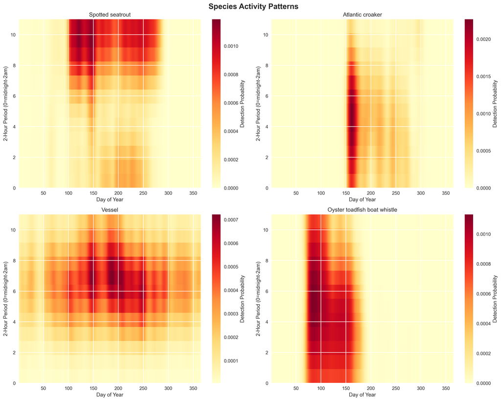

**Atlantic Croaker**: More variable patterns, suggesting complex behavioral responses

### The Kernel Density Estimation Breakthrough

To transform these scattered detection points into smooth, usable probability surfaces, we employed a mathematical technique called **kernel density estimation (KDE)**.

Think of each fish detection as dropping a pebble into a pond - the ripples spread out, creating areas of influence around the detection point. KDE does something similar mathematically, creating smooth “probability ripples” around each observed detection.

[figure not shown]

*Figure 8: Illustration of how kernel density estimation transforms scattered detection points into smooth probability surfaces that can guide monitoring efforts.*

## The Detection Guidance System: From Patterns to Practice

### How the System Works

1. **Historical Pattern Learning**: Analyze years of detection data to build species-specific 2D probability surfaces
2. **Environmental Enhancement**: Adjust base probabilities using current acoustic and environmental conditions
3. **Priority Ranking**: Rank all time periods by detection probability
4. **Guided Monitoring**: Focus manual detection efforts on the highest-ranked periods

[figure not shown]

*Figure 9: Flowchart showing how the detection guidance system converts historical patterns and current conditions into prioritized monitoring recommendations.*

### Performance: The Numbers That Matter

When we tested our system using **cross-station validation** (training on two listening stations, testing on the third), the results exceeded our expectations:

**Silver Perch: The Success Story** - **86.6% of all detections found** by checking only the top 20% of time periods - **80% reduction in manual effort** while maintaining high detection rates - **Consistent performance** across all three monitoring stations

**Oyster Toadfish: The Spawning Specialist** - **69.2% detection efficiency** at 20% effort threshold - **AUC = 0.944**: Nearly perfect discrimination ability - **Biological validation**: System correctly identified known spawning seasons

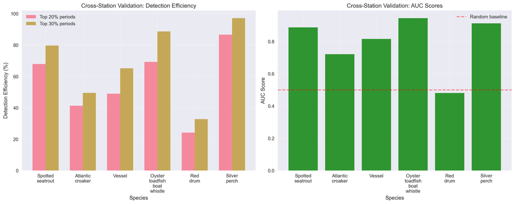

*Figure 10: Detection efficiency results showing percentage of actual detections captured when checking different proportions of highest-ranked time periods.*

### Why Some Species Worked Better Than Others

**Moderate Performers (Spotted seatrout)**: - Good seasonal patterns but more variable daily timing - Adequate detection counts for pattern recognition - Some location-specific behavioral differences

**Challenging Cases (Atlantic croaker, Red drum)**: - Irregular temporal patterns (less predictable behavior) - Lower detection rates (fewer pattern examples) - High variability between monitoring stations - Possible habitat-specific behavioral adaptations

[figure not shown]

*Figure 11: Analysis of why different species show varying levels of predictability, relating performance to biological characteristics and detection frequency.*

## Real-World Impact: From Research to Conservation

### The Time Savings Revolution

[figure not shown]

*Figure 12: Comparison of traditional vs. guided monitoring approaches, showing dramatic reductions in required effort while maintaining high detection sensitivity.*

### Conservation Applications

**Spawning Season Monitoring**: - Quickly identify critical reproductive periods for protection - Focus enforcement efforts during high-activity times - Monitor recovery of fish populations after conservation measures

**Climate Change Research**: - Track shifts in seasonal timing as ocean temperatures change - Identify species most vulnerable to thermal stress - Document ecosystem-wide changes in biological rhythms

**Marine Protected Area Management**: - Optimize monitoring schedules for limited research budgets - Provide evidence-based timing for fishing restrictions - Track effectiveness of protection measures

**Ecosystem Health Assessment**: - Use vocal activity as an indicator of population health - Identify areas with declining biological activity - Prioritize locations for conservation intervention

### The Bigger Picture: Acoustic Monitoring at Scale

Our detection guidance system addresses one of the biggest bottlenecks in marine conservation: **the gap between data collection and actionable insights**.

Ocean monitoring networks are generating acoustic data faster than ever before, but most of it sits unanalyzed due to the manual labor required for species detection. By reducing this workload by 80% while maintaining scientific accuracy, our system makes large-scale, multi-species acoustic monitoring practically feasible.

[figure not shown]

*Figure 13: Visualization showing how efficiency gains enable monitoring at previously impossible scales, from single stations to regional networks.*

## What We Learned: Scientific and Technical Insights

### Biological Discoveries

**Temperature Rules Everything**: Confirming and extending Transue et al.’s findings, water temperature emerged as the master variable controlling fish vocal activity. But we discovered that **temperature trends** (warming vs. cooling) can be as important as absolute temperature.

**Species-Specific Rhythms**: Each fish species has evolved distinct temporal patterns that reflect their ecological niche, reproductive strategy, and evolutionary history. These patterns are remarkably consistent across different locations.

**The Power of Seasonality**: Rather than treating seasonality as a problem to solve, embracing it as a biological feature led to our breakthrough. Marine ecosystems operate on predictable seasonal rhythms that can be leveraged for efficient monitoring.

**Acoustic Indices Matter**: While environmental variables like temperature are the primary drivers, acoustic indices provide complementary information that improves detection guidance, especially during transition periods between seasons.

### Technical Innovations

**2D Pattern Recognition**: Moving from 1D time series analysis to 2D probability surfaces revealed patterns invisible to traditional approaches.

**Cross-Station Validation**: Testing models across different monitoring locations provides more realistic performance estimates than traditional time-based validation.

**Biological Feature Engineering**: Incorporating expert knowledge about marine biology into mathematical features improved model performance and interpretability.

**Guidance vs. Prediction**: Shifting from predictive modeling to pattern recognition and guidance systems proved more practical and robust for real-world applications.

### Methodological Lessons

**Work with Biology, Not Against It**: Systems that align with natural biological patterns are more robust and interpretable than those that ignore ecological context.

**Cross-Validation Strategy Matters**: How you validate your model dramatically affects whether it will work in the real world. Spatial validation (cross-station) gave us confidence that wouldn’t have emerged from temporal validation alone.

**Feature Engineering is Crucial**: The way you represent your data to machine learning models determines what patterns they can discover. Biological expertise is essential for effective feature engineering.

**Simple Can Be Better**: Our most successful approach used relatively simple kernel density estimation rather than complex deep learning models. Understanding your problem thoroughly often leads to simpler, more effective solutions.

## Limitations and Future Directions

### Current Limitations

**Single-Year Training Data**: Our models are based on 2021 data only. Multi-year validation will be essential to confirm that patterns are consistent across different environmental conditions and climate variability.

**Geographic Scope**: All three monitoring stations were in similar coastal environments. Performance in different habitat types (open ocean, coral reefs, estuaries) remains to be tested.

**Species Coverage**: Our approach works best for species with strong temporal patterns and sufficient detection events. Rare species or those with irregular behavior remain challenging.

**Manual Validation Required**: The system provides guidance, not automated detection. Expert validation is still necessary, though much more efficient.

### Near-Term Enhancements

**Multi-Year Validation**: As additional years of data become available, we can test whether biological patterns remain stable across different climate conditions and environmental variability.

**Adaptive Thresholds**: Develop species-specific and location-specific thresholds that optimize the trade-off between detection efficiency and manual effort.

**Real-Time Implementation**: Adapt the system for real-time monitoring applications where acoustic data is transmitted continuously from underwater monitoring stations.

**Multi-Species Integration**: Develop combined probability surfaces that optimize monitoring for multiple target species simultaneously.

### Long-Term Vision

**Regional Network Deployment**: Scale the approach to work across large networks of acoustic monitoring stations, enabling ecosystem-wide assessments of marine biodiversity.

**Climate Change Monitoring**: Use shifts in temporal patterns as early indicators of climate change impacts on marine ecosystems.

**AI-Assisted Detection**: Combine pattern guidance with automated detection algorithms to create hybrid systems that maximize both efficiency and accuracy.

**Integration with Other Monitoring**: Combine acoustic guidance with visual surveys, environmental DNA sampling, and satellite monitoring for comprehensive ecosystem assessment.

## Conclusions: A New Era for Marine Acoustic Monitoring

### Scientific Impact

This work demonstrates that **marine acoustic monitoring can be transformed from a manual bottleneck into a scalable research tool**. By revealing the hidden temporal patterns in ocean soundscapes, we’ve opened new avenues for understanding marine ecosystem dynamics.

Our findings confirm that biological systems operate on predictable rhythms that can be mathematically described and practically leveraged. The 2D probability surfaces we developed provide not just operational guidance, but scientific insights into the temporal ecology of marine species.

### Conservation Applications

The 80% reduction in manual effort while maintaining high detection sensitivity makes comprehensive acoustic monitoring feasible for resource-limited conservation programs. This efficiency gain could enable:

- **Ecosystem-wide monitoring** of fish populations
- **Rapid assessment** of marine protected area effectiveness
- **Early detection** of ecosystem changes due to climate change or human impacts
- **Evidence-based timing** for fishing restrictions and conservation measures

### The Broader Lesson

Perhaps most importantly, this work illustrates how **collaboration between domain expertise and data science** can solve seemingly intractable problems. The breakthrough came not from applying more sophisticated algorithms, but from asking better questions informed by marine biology.

By embracing the seasonal nature of marine ecosystems rather than fighting it, we found patterns that were hiding in plain sight. Sometimes the solution isn’t more complex models - it’s understanding your problem deeply enough to ask the right questions.

### Looking Forward

As ocean monitoring networks expand and acoustic monitoring becomes more widespread, tools like our detection guidance system will become essential infrastructure for marine conservation. The patterns we’ve revealed in coastal fish communities likely exist throughout marine ecosystems - we just need to listen for them.

The ocean is full of sounds, and those sounds tell stories about the health and abundance of marine life. With the right tools to guide our listening, we can finally hear what the ocean has been trying to tell us.

## References

Transue, B., et al. (2023). Biological and anthropogenic soundscape of an urbanized port: Charleston Harbor. *Marine Environmental Research*.

*This report represents a comprehensive analysis of marine acoustic monitoring data, demonstrating how innovative approaches to temporal pattern recognition can transform our ability to monitor and understand ocean ecosystems.*